# Principios y Prácticas de SEM y MLM (5ed)

Tema 1.3 Análisis de Moderación

Author

Efraín García Sánchez

Published

August 5, 2026

# Principios

## Modelos de regresión lineal (con terceras variables)

#### Regresión (todos los paneles)

- ¿cuál es la relación/efecto de *X* sobre *Y*, manteniendo otras variables *W’s* constantes?

#### Moderación (interacción; Panel B):

- ¿Cuándo? ¿para quién? ¿bajo qué condición o circunstancia sucede esa relación?

#### Mediación (proceso; Panel A):

- ¿Cómo? ¿cuál es el mecanismo o proceso que explica esa relación?

#### Mediación moderada o “*conditional process analyses*” (Panel C y D)

- ¿Cuándo o bajo qué circunstancias opera el mecanismo o proceso?

[figure not shown]

## ¿Cuándo se usan los análisis de moderación?

- Para saber si el efecto de una variable `X` sobre otra `Y`, depende de una tercera variable `W`
- Evaluar si hay un efecto combinado de dos variables `X`:`W` sobre otra
- ¿El efecto de X sobre Y depende de W?
  - “unconditional”: pendientes paralelas, el efecto no cambia (Panel A)
  - “conditional”: pendientes diferentes, el efecto cambia (Panel B)
- ¿Cómo sé si una variable es moderadora o mediadora?
  - Depende de la plausibilidad teórica, naturaleza del fenómeno
  - Las mismas variables pueden tener diferentes roles en diferentes modelos –> Hipótesis
  - Poco usual que las mismas variables tengan diferentes roles en el mismo modelo

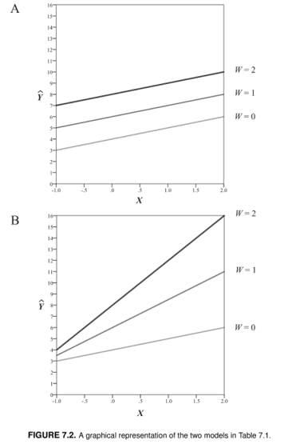

## ¿Cuándo se usan los análisis de moderación?

- Moderación (conceptual) = Interacción (estadístico)
- Evaluar si el efecto de una variable sobre otra depende de una tercera variable
  - El efecto de X sobre Y, depende de W
  - El efecto de X sobre Y en diferentes niveles de W
- Preguntas:
  - ¿Cuándo ocurre el efecto? (cuando es estadísticamente significativo)
  - ¿Cuando se fortalece o se debilita el efecto?
  - ¿Cuándo cambia la dirección del efecto?

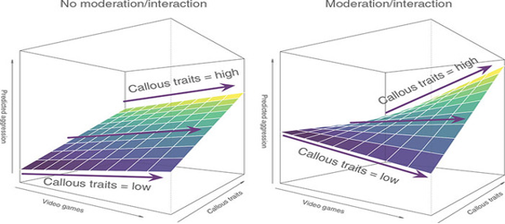

## Formas o Tipos de interacción

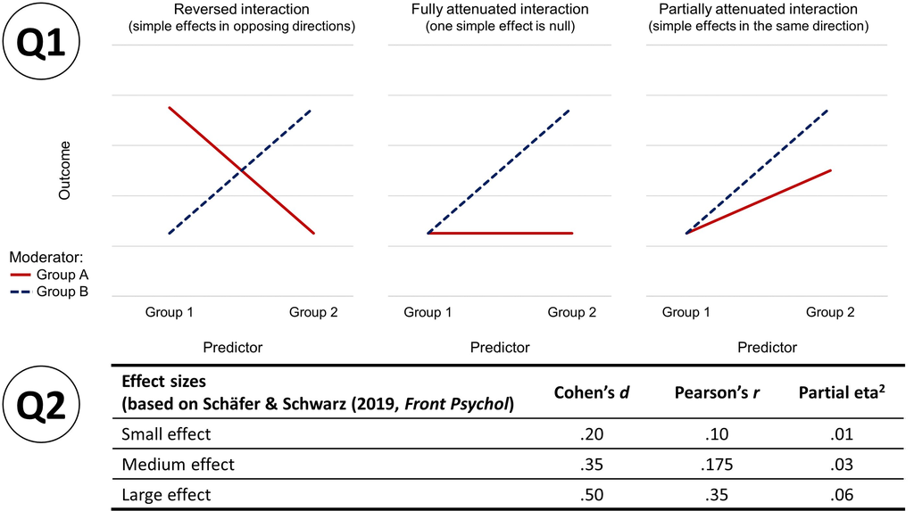

[Sommet (2022)](https://twitter.com/nicolas_sommet/status/1567827960542945285/photo/1)

## Ejemplo de moderación

Ejemplo:

> La relación entre jugar videojuegos y la agresividad es positiva, es **Positiva y estadísticamente significativa** *sólo* para las personas que son más insensibles/desconsideradas con los otros.

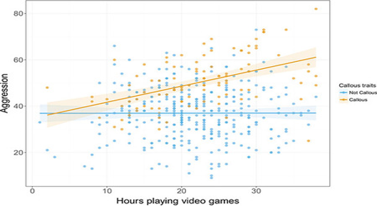

## Representación matemática y visual de una interacción

- Efecto linear de `videojuego` y `sensibilidad`
  $$Y_{agresividad} = i_{agresividad} + b_1*X_{1_{videojuego}} + b_2*X_{2_{insensibilidad}} + error$$
- Efecto combinado
  $$Y_{agresividad} = i_{agresividad} + b_1*X_{1_{videojuego}} + b_2*X_{2_{insensibilidad}} + b_3*(X_{1_{videojuego}}*X_{2_{insensibilidad}}) + error$$

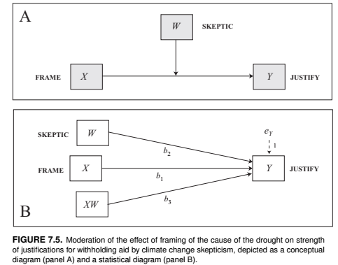

Hayes (2022)

## Supuestos

#### Igual que en la regresión

- Forma funcional adecuada (relaciones lineales)
- Relevancia de las variables (no omitir variables clave)
- Residuos no correlacionados
- Homocedasticidad
- Multicolinealidad

#### Teórico y práctico

- La predictora **no debería causar/predicir** la moderadora.
- La moderadora no suele ser un proceso, sino una condición o diferencia individual.
- Conviene evitar una relación excesivamente fuerte entre `X` y `W`.

## Centrar las variables ayuda a la interpretación de la interacción

- Recordar
  - $b_1$ = Cambio en `Y` por cada unidad de cambio en `X`, cuando los otros predictores `W` *son iguales a cero*.
  - ¿que pasa si la covariable `edad = 0`?
- **Solución**: Transformar las variables
  - En función de una constante (punto de referencia: la **Media**)
  - *Grand Mean Centering*: Sustraer la media a todas las variables $(x_i - \overline{X})$
  - *Práctico*: Valor que facilite la interpretación (e.g., edad, peso, etc.)
- Nota 1: Centrar una variable **NO** cambia el efecto de la interacción $b_3$, pero sí el de los predictores individuales ($b_1$ y $b_2$).
- Nota 2: No cambia el test de significancia $(p)$
- **Interpretación**
  - Intercepto: la media de `Y` cuando los predictores son iguales a $0$
  - Valor de $b_1$ cuando $b_2$ es igual a $0$

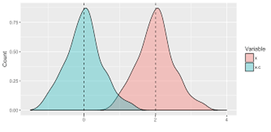

## Evaluar y probar la interacción (*testing* y *probing*)

### Testing

- Determina si la interacción es **estadísticamente significativa**.
- Evalúa si la combinación de dos variables se asocia con la variable resultado.
- Indica si el efecto de `X` sobre `Y` está condicionado por `W`.

$$Y = b_0 + b_1X + b_2W + b_3(XW) + error$$

### Probing

- Determina en qué valores de la moderadora se observa el efecto.
- Estima si el efecto de `X` sobre `Y` es diferente de cero a distintos valores de `W`.
- Incluye pendientes simples, efectos marginales y Johnson-Neyman.

$$Efecto_X = b_1 + b_3W$$

## Evaluar las pendientes simples (testing simple slopes)

- Interpretación:
  - La diferencia en `Y` por cada unidad de cambio en `X` está influenciada por `W`
  - `b3` indica cuánto cambia el efecto de `X` cuando cambia `W`
  - También puede interpretarse como cuánto cambia el efecto de `W` cuando cambia `X`

$$Y = b_0 + b_1X + b_2W + b_3XW + error$$

$$Y = b_0 + (b_1 + b_3W)X + b_2W + error$$

$$Y = b_0 + b_1X + (b_2 + b_3X)W + error$$

## Probar las interacciones (*Probing*)

- **“Pick-a-point Approach”**
  - Media y +/- 1 SD (más común, pero con advertencias)
  - Percentile 16, 50 y 84 (cuando no es normal)
  - A criterio del/a investigador/a (ej. edad)

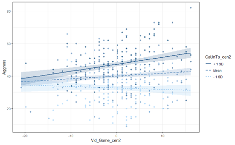

- **Johnson-Neyman**
- Sólo con moderadores continuos
- Valores de W donde el efecto conditional de X sobre Y es significativo y no significativo; positivo y negativo
- Atención a las regiones dónde los valores no cruzan el cero

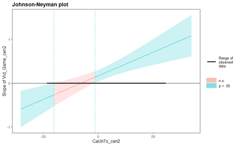

## Reportar las moderaciones: Texto, tablas y figuras

> El efecto de la interacción fue estadísticamente significativo (b = 0.90, SE = 0.03, t(156) = 4.56, p < .001, 95% CI [0.85, 0.95]). El análisis de las pendientes simples (*simple slope analyses*) indican que el efecto fue positivo y estadísticamente significativo para las personas con altos niveles de X (+1SD) (b = 0.99, SE = 0.03, p < .001), mientras que el efecto no fue estadísticamente significativo para las personas con bajos niveles de X (-1SD) (b = 0.05, SE = 0.05, p = .593))

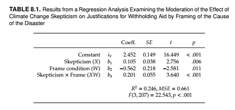

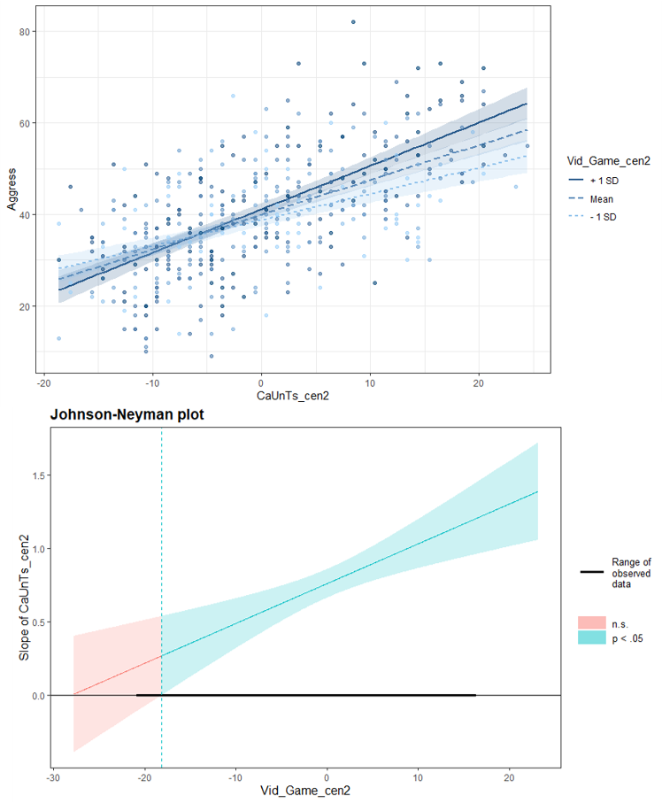

## Tener en cuenta el tamaño de la muestra para las interacciones

- Aplicación: [intxpower](https://intxpower.com/)
- [Sommet (2023)](https://journals.sagepub.com/doi/10.1177/25152459231178728)

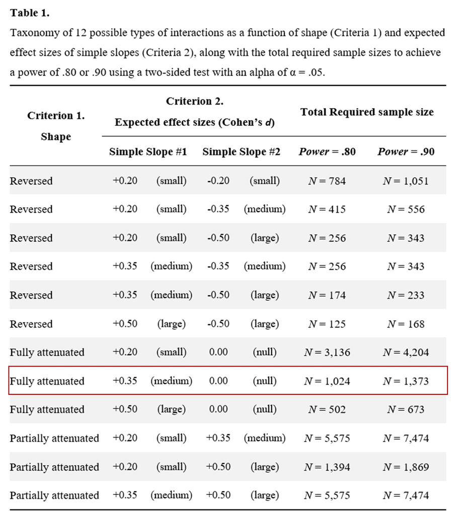

[Sommet (2022)](https://twitter.com/nicolas_sommet/status/1567827967786602496/photo/1)

# Práctica

## Preparar el ambiente de trabajo (instalar, si no están instalados)

```r
# install.packages("tidyverse")        # manipulación y visualización de datos
# install.packages("easystats")        # Paquetes para análisis estadísticos
# install.packages("sjPlot")           # para visualización de resultados
# install.packages("sjmisc")           # funciones para manipulación de datos
# install.packages("marginaleffects")  # estimar predicciones, contrastes y pendientes
# install.packages("emmeans")          # estima medias marginales
# install.packages("sjPlot")           # para reportar tablas y figuras
```

## Preparar el ambiente de trabajo (cargar los paquetes)

```r
library(tidyverse)        # manipulación y visualización de datos
library(easystats)        # Paquetes para análisis estadísticos
library(sjPlot)           # para visualización de resultados
library(sjmisc)           # funciones para manipulación de datos
library(marginaleffects)  # estimar predicciones, contrastes y pendientes
library(emmeans)          # estima medias marginales
library(sjPlot)           # para reportar tablas y figuras
```

## Importar los datos: con etiquetas (para conservar los labels)

```r
data_labels <- haven::read_sav(
  here::here("../data/northampton_student_health_data_package/northampton_student_health_labelled.sav"))

glimpse(data_labels)
```

```
Rows: 590
Columns: 61
$ id                             <dbl> 1, 2, 3, 4, 5, 6, 7, 8, 9, 10, 11, 12, …
$ age_group                      <dbl+lbl> 1, 1, 1, 1, 1, 1, 2, 4, 1, 1, 1, 1,…
$ gender                         <dbl+lbl> 2, 1, 1, 1, 1, 2, 1, 1, 2, 2, 2, 2,…
$ sexual_orientation             <dbl+lbl> 1, 2, 1, 3, 1, 1, 1, 1, 1, 1, 1, 1,…
$ ethnicity                      <dbl+lbl> 1, 1, 1, 2, 1, 3, 1, 1, 1, 3, 1, 1,…
$ study_mode                     <dbl+lbl> 1, 1, 1, 1, 1, 1, 1, 2, 1, 1, 1, 1,…
$ study_level                    <dbl+lbl> 3, 3, 3, 3, 2, 6, 4, 3, 1, 2, 1, 1,…
$ living_situation               <dbl+lbl> 1, 2, 1, 3, 2, 4, 3, 3, 1, 2, 4, 1,…
$ phys_health                    <dbl+lbl> 3, 4, 4, 3, 4, 5, 5, 1, 4, 4, 4, 5,…
$ ment_health                    <dbl+lbl> 4, 3, 2, 4, 3, 3, 2, 1, 4, 4, 3, 5,…
$ social_connect                 <dbl+lbl> 4, 3, 1, 1, 2, 3, 2, 4, 4, 3, 3, 3,…
$ sitting_weekday_hours          <dbl> 8, 5, 7, 9, NA, 5, 11, 13, 6, 5, 12, 6,…
$ sleep_quality                  <dbl> 8, 7, 4, 7, 2, 5, 3, 8, 7, 2, 9, 7, 3, …
```

[output cut: 48 more lines]

## Importar los datos: solo numéricos (para facilitar la manipulación)

```r
data <- readr::read_csv(
  here::here("../data/northampton_student_health_data_package/northampton_student_health_numeric.csv"))

glimpse(data)
```

```
Rows: 590
Columns: 61
$ id                             <dbl> 1, 2, 3, 4, 5, 6, 7, 8, 9, 10, 11, 12, …
$ age_group                      <dbl> 1, 1, 1, 1, 1, 1, 2, 4, 1, 1, 1, 1, 1, …
$ gender                         <dbl> 2, 1, 1, 1, 1, 2, 1, 1, 2, 2, 2, 2, 2, …
$ sexual_orientation             <dbl> 1, 2, 1, 3, 1, 1, 1, 1, 1, 1, 1, 1, 1, …
$ ethnicity                      <dbl> 1, 1, 1, 2, 1, 3, 1, 1, 1, 3, 1, 1, 1, …
$ study_mode                     <dbl> 1, 1, 1, 1, 1, 1, 1, 2, 1, 1, 1, 1, 1, …
$ study_level                    <dbl> 3, 3, 3, 3, 2, 6, 4, 3, 1, 2, 1, 1, 1, …
$ living_situation               <dbl> 1, 2, 1, 3, 2, 4, 3, 3, 1, 2, 4, 1, 1, …
$ phys_health                    <dbl> 3, 4, 4, 3, 4, 5, 5, 1, 4, 4, 4, 5, 5, …
$ ment_health                    <dbl> 4, 3, 2, 4, 3, 3, 2, 1, 4, 4, 3, 5, 3, …
$ social_connect                 <dbl> 4, 3, 1, 1, 2, 3, 2, 4, 4, 3, 3, 3, 2, …
$ sitting_weekday_hours          <dbl> 8, 5, 7, 9, NA, 5, 11, 13, 6, 5, 12, 6,…
$ sleep_quality                  <dbl> 8, 7, 4, 7, 2, 5, 3, 8, 7, 2, 9, 7, 3, …
```

[output cut: 48 more lines]

## Transformar los datos y recodificar variables (igual que antes)

```r
data <- data |>
  mutate(# creo variable dummy para género (Female vs Male)
         gender_female = case_when(gender == 1 ~ 1, # Female
                                   gender == 2 ~ 0, # Male
                                   .default = NULL),
         # creo una variable de etnia para los grupos más grandes
         ethnicity_cat = case_when(ethnicity == 1 ~ "White",
                                 ethnicity == 3 ~ "Black",
                                 ethnicity == 4 ~ "Asian",
                                 TRUE ~ NA_character_),
         # ordeno la variable de etnia en niveles (White es la referencia)
         ethnicity_cat = factor(ethnicity_cat,
                                levels = c("White", "Black", "Asian")),
         # Creo una variable dummy para ver diferencias con White
         ethnicity_black = ifelse(test = ethnicity_cat == "Black",
                                  yes = 1, no = 0),
         ethnicity_asian = ifelse(test = ethnicity_cat == "Asian",
                                  yes = 1, no = 0),
         # creo una variable categórica con pa_activity
         pa_activity_level_cat = case_when(pa_activity_level == 0 ~ "0_Inactive",
                                       pa_activity_level == 1 ~ "1_Fairly_Active",
                                       pa_activity_level == 2 ~ "2_Active")
         )
```

## Centrar las variables

```r
data <- data |>
  mutate(
    # manualmente
    alcohol_freq_cen = as.numeric(scale(alcohol_freq, center = TRUE, scale = FALSE)),
    alcohol_freq_z = as.numeric(scale(alcohol_freq, center = TRUE, scale = TRUE))
    )
```

```r
# visualizar los datos
data |>
  dplyr::select(alcohol_freq, alcohol_freq_cen, alcohol_freq_z)
```

```
# A tibble: 590 × 3
   alcohol_freq alcohol_freq_cen alcohol_freq_z
          <dbl>            <dbl>          <dbl>
 1            2            0.515          0.303
 2            1           -0.485         -0.285
 3            1           -0.485         -0.285
 4            1           -0.485         -0.285
 5            4            2.52           1.48
 6            1           -0.485         -0.285
 7            1           -0.485         -0.285
 8            5            3.52           2.07
 9            5            3.52           2.07
10            1           -0.485         -0.285
# ℹ 580 more rows
```

```r
# visualizar los datos
data |>
  dplyr::select(alcohol_freq, alcohol_freq_cen, alcohol_freq_z) |>
  psych::describe()
```

```
                 vars   n mean  sd median trimmed  mad   min  max range skew
alcohol_freq        1 590 1.48 1.7   1.00    1.24 1.48  0.00 7.00  7.00 0.94
alcohol_freq_cen    2 590 0.00 1.7  -0.48   -0.25 1.48 -1.48 5.52  7.00 0.94
alcohol_freq_z      3 590 0.00 1.0  -0.28   -0.14 0.87 -0.87 3.24  4.11 0.94
                 kurtosis   se
alcohol_freq        -0.29 0.07
alcohol_freq_cen    -0.29 0.07
alcohol_freq_z      -0.29 0.04
```

## Modelos de regresión lineal: efectos simples

```r
m0 <- lm(ment_health ~ 1, data = data)

m1 <- lm(ment_health ~ alcohol_freq + pa_activity_level, data = data)

m2 <- lm(ment_health ~ alcohol_freq_cen + pa_activity_level,data = data)

m3 <- lm(ment_health ~ alcohol_freq_z + pa_activity_level,data = data)

# ver los resultados
parameters::compare_parameters(m0, m1, m2, m3) |>
  parameters::display()
```

| Parameter | m0 | m1 | m2 | m3 |
| --- | --- | --- | --- | --- |
| (Intercept) | 3.45 (3.36, 3.53) | 3.36 ( 3.16, 3.56) | 3.23 ( 3.04, 3.42) | 3.23 ( 3.04, 3.42) |
| pa activity level |  | 0.18 ( 0.04, 0.32) | 0.18 ( 0.04, 0.32) | 0.18 ( 0.04, 0.32) |
| alcohol freq |  | -0.09 (-0.14, -0.04) |  |  |
| alcohol freq cen |  |  | -0.09 (-0.14, -0.04) |  |
| alcohol freq z |  |  |  | -0.15 (-0.23, -0.06) |
| Observations | 590 | 590 | 590 | 590 |

## Inspeccionar los resultados

```r
sjPlot::tab_model(m0, m1, m2, m3,
                  show.ci = FALSE,
                  dv.labels = c("M0. (intercepto = media)",
                                "M1. (Datos brutos)",
                                "M2. (Variable centrada)",
                                "M3.(Variable centrada y estandarizada"),
                  show.stat = TRUE)
```

|  | M0. (intercepto = media) |  |  | M1. (Datos brutos) |  |  | M2. (Variable centrada) |  |  | M3.(Variable centrada y estandarizada |  |  |
| --- | --- | --- | --- | --- | --- | --- | --- | --- | --- | --- | --- | --- |
| Predictors | Estimates | Statistic | p | Estimates | Statistic | p | Estimates | Statistic | p | Estimates | Statistic | p |
| (Intercept) | 3.45 | 79.48 | **<0.001** | 3.36 | 33.72 | **<0.001** | 3.23 | 34.02 | **<0.001** | 3.23 | 34.02 | **<0.001** |
| alcohol freq |  |  |  | -0.09 | -3.43 | **0.001** |  |  |  |  |  |  |
| pa activity level |  |  |  | 0.18 | 2.55 | **0.011** | 0.18 | 2.55 | **0.011** | 0.18 | 2.55 | **0.011** |
| alcohol freq cen |  |  |  |  |  |  | -0.09 | -3.43 | **0.001** |  |  |  |
| alcohol freq z |  |  |  |  |  |  |  |  |  | -0.15 | -3.43 | **0.001** |
| Observations | 590 |  |  | 590 |  |  | 590 |  |  | 590 |  |  |
| R<sup>2</sup> / R<sup>2</sup> adjusted | 0.000 / 0.000 |  |  | 0.028 / 0.025 |  |  | 0.028 / 0.025 |  |  | 0.028 / 0.025 |  |  |

- El intercepto cambia: la media de `Y` cuando el predictor es `0`
- El coeficiente de regresión no cambia si la variable está centrada o no
- El coeficiente cambia cuando se estandariza (la unidad de medida ha cambiado)
- La Varianza explicada no cambia

## Comparar los modelos

- El `m0` difiere de `m1`, pero de resto son iguales

```r
anova(m0, m1, m2, m3)
```

```
Analysis of Variance Table

Model 1: ment_health ~ 1
Model 2: ment_health ~ alcohol_freq + pa_activity_level
Model 3: ment_health ~ alcohol_freq_cen + pa_activity_level
Model 4: ment_health ~ alcohol_freq_z + pa_activity_level
  Res.Df    RSS Df Sum of Sq      F    Pr(>F)
1    589 653.87
2    587 635.49  2    18.378 8.4876 0.0002324 ***
3    587 635.49  0     0.000
4    587 635.49  0     0.000
---
Signif. codes:  0 '***' 0.001 '**' 0.01 '*' 0.05 '.' 0.1 ' ' 1
```

## Comparar los modelos `performance::compare_performance()`

```r
performance::compare_performance(m0, m1, m2, m3) |>
  parameters::display()
```

| Name | Model | AIC (weights) | AICc (weights) | BIC (weights) | R2 | R2 (adj.) | RMSE | Sigma |
| --- | --- | --- | --- | --- | --- | --- | --- | --- |
| m0 | lm | 1739.0 (<.001) | 1739.0 (<.001) | 1747.8 (0.04) | 0.00 | 0.00 | 1.05 | 1.05 |
| m1 | lm | 1726.2 (0.33) | 1726.2 (0.33) | 1743.7 (0.32) | 0.03 | 0.02 | 1.04 | 1.04 |
| m2 | lm | 1726.2 (0.33) | 1726.2 (0.33) | 1743.7 (0.32) | 0.03 | 0.02 | 1.04 | 1.04 |
| m3 | lm | 1726.2 (0.33) | 1726.2 (0.33) | 1743.7 (0.32) | 0.03 | 0.02 | 1.04 | 1.04 |

## Modelos de regresión lineal: efectos combinados (interacción)

```r
m1a <- lm(ment_health ~ alcohol_freq*pa_activity_level,
         data = data)

m2a <- lm(ment_health ~ alcohol_freq_cen*pa_activity_level,
         data = data)

m3a <- lm(ment_health ~ alcohol_freq_z*pa_activity_level,
         data = data)

parameters::compare_parameters(m1, m1a, m2, m2a, m3, m3a) |>
  parameters::display()
```

| Parameter | m1 | m1a | m2 | m2a | m3 | m3a |
| --- | --- | --- | --- | --- | --- | --- |
| (Intercept) | 3.36 ( 3.16, 3.56) | 3.11 ( 2.87, 3.34) | 3.23 ( 3.04, 3.42) | 3.25 ( 3.06, 3.43) | 3.23 ( 3.04, 3.42) | 3.25 ( 3.06, 3.43) |
| pa activity level | 0.18 ( 0.04, 0.32) | 0.41 ( 0.22, 0.59) | 0.18 ( 0.04, 0.32) | 0.18 ( 0.04, 0.32) | 0.18 ( 0.04, 0.32) | 0.18 ( 0.04, 0.32) |
| alcohol freq | -0.09 (-0.14, -0.04) | 0.10 (-0.01, 0.20) |  |  |  |  |
| alcohol freq × pa activity level |  | -0.15 (-0.23, -0.07) |  |  |  |  |
| alcohol freq cen |  |  | -0.09 (-0.14, -0.04) | 0.10 (-0.01, 0.20) |  |  |
| alcohol freq cen × pa activity level |  |  |  | -0.15 (-0.23, -0.07) |  |  |
| alcohol freq z |  |  |  |  | -0.15 (-0.23, -0.06) | 0.16 (-0.02, 0.35) |
| alcohol freq z × pa activity level |  |  |  |  |  | -0.26 (-0.40, -0.12) |
| Observations | 590 | 590 | 590 | 590 | 590 | 590 |

## Modelos de regresión lineal: efectos combinados (interacción)

```r
sjPlot::tab_model(m1, m1a, m2, m2a, m3, m3a,
                  dv.labels = c("M1. (Datos brutos)","M1a. (Datos brutos + interacción)",
                                "M2. (centrada)","M2a. (centrada + interacción)",
                                "M3.(estandarizada","M3a. (estandarizada + interacción)"),
                  show.ci = FALSE,
                  show.p = FALSE)
```

|  | M1. (Datos brutos) | M1a. (Datos brutos + interacción) | M2. (centrada) | M2a. (centrada + interacción) | M3.(estandarizada | M3a. (estandarizada + interacción) |
| --- | --- | --- | --- | --- | --- | --- |
| Predictors | Estimates | Estimates | Estimates | Estimates | Estimates | Estimates |
| (Intercept) | 3.36 | 3.11 | 3.23 | 3.25 | 3.23 | 3.25 |
| alcohol freq | -0.09 | 0.10 |  |  |  |  |
| pa activity level | 0.18 | 0.41 | 0.18 | 0.18 | 0.18 | 0.18 |
| alcohol freq × pa activity level |  | -0.15 |  |  |  |  |
| alcohol freq cen |  |  | -0.09 | 0.10 |  |  |
| alcohol freq cen × pa activity level |  |  |  | -0.15 |  |  |
| alcohol freq z |  |  |  |  | -0.15 | 0.16 |
| alcohol freq z × pa activity level |  |  |  |  |  | -0.26 |
| Observations | 590 | 590 | 590 | 590 | 590 | 590 |
| R<sup>2</sup> / R<sup>2</sup> adjusted | 0.028 / 0.025 | 0.050 / 0.046 | 0.028 / 0.025 | 0.050 / 0.046 | 0.028 / 0.025 | 0.050 / 0.046 |

## Verificar los supuestos: Sólo para el modelo con efectos simples

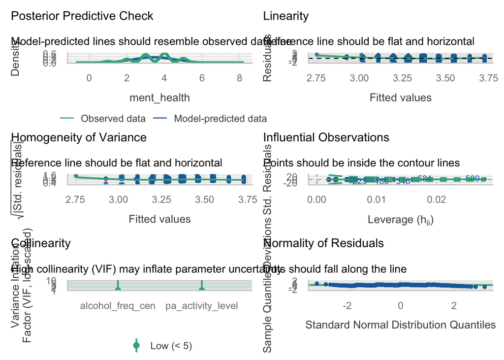

```r
performance::check_model(m2)
```

## Verificar los supuestos: NO se hace con la interacción (multicolinealidad)

```r
performance::check_collinearity(m1a)
```

```
# Check for Multicollinearity

Low Correlation

              Term  VIF   VIF 95% CI adj. VIF Tolerance Tolerance 95% CI
      alcohol_freq 4.88 [4.24, 5.65]     2.21      0.20     [0.18, 0.24]
 pa_activity_level 1.72 [1.55, 1.95]     1.31      0.58     [0.51, 0.64]

Moderate Correlation

                           Term  VIF   VIF 95% CI adj. VIF Tolerance
 alcohol_freq:pa_activity_level 5.85 [5.07, 6.79]     2.42      0.17
 Tolerance 95% CI
     [0.15, 0.20]
```

## Interpretar la interacción: Evaluar las pendientes simples (*Simple slope analysis*)

```r
modelbased::estimate_slopes(model = m2a,
                            trend = "alcohol_freq_cen",    # Predictora
                            by = "pa_activity_level")     # Moderadora
```

```
Estimated Marginal Effects

pa_activity_level | Slope |   SE |         95% CI | t(586) |      p
-------------------------------------------------------------------
0                 |  0.10 | 0.06 | [-0.01,  0.20] |   1.74 |  0.083
1                 | -0.06 | 0.03 | [-0.11, -0.01] |  -2.19 |  0.029
2                 | -0.21 | 0.04 | [-0.29, -0.13] |  -5.05 | < .001

Marginal effects estimated for alcohol_freq_cen
Type of slope was dY/dX
```

- `pa_activity_level` como moderador
- El efecto de `alcohol_freq_cen` sobre `ment_health`, a diferentes valores de `pa_activity_level` [0 (`Inactive`), 1 (`Fairly active`) y 2 `Active`]

## Interpretar la interacción: Evaluar las pendientes simples de forma visual (*Simple slope analysis*)

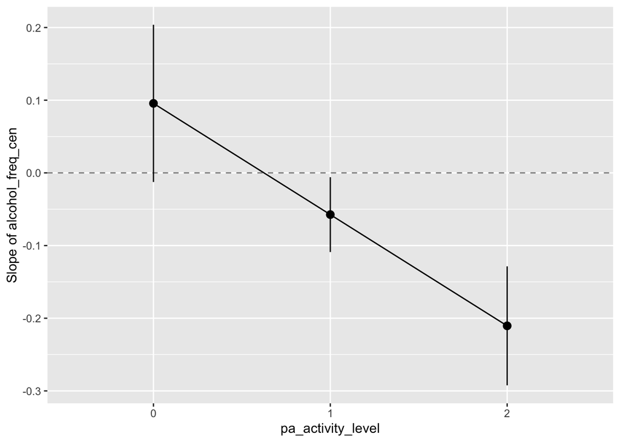

```r
modelbased::estimate_slopes(model = m2a,
                            trend = "alcohol_freq_cen",    # Predictora
                            by = "pa_activity_level")  |>
  plot()
```

## Interpretar la interacción: Visualizar las pendientes simples (*Simple slope analysis*)

- Las medias marginales ajustadas (*adjusted marginal means*) en `salud mental` (*dependiente*) por `frecuencia de consumo de alcohol` (*predictora*), en función de la `actividad física` (*moderadora*)

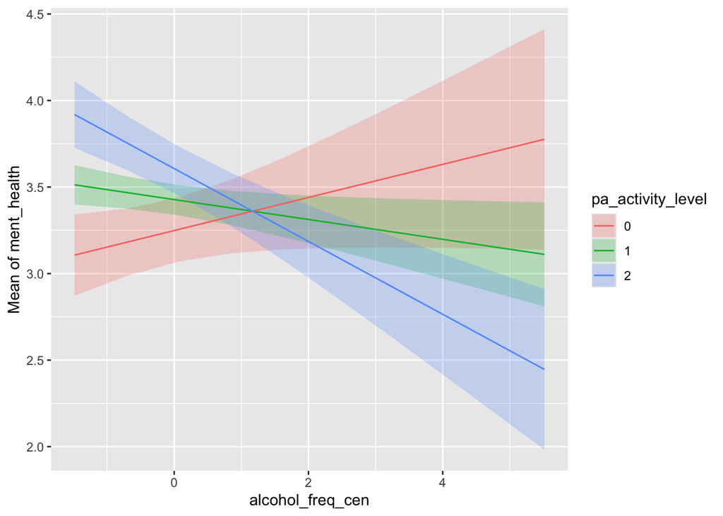

```r
modelbased::estimate_means(model = m2a,
                           by = c("alcohol_freq_cen", "pa_activity_level")) |>
  plot()
```

## Interpretar la interacción: Visualizar las pendientes simples (*Simple slope analysis*) (ajustado para publicación)

- Se puede adaptar la figura para formato de publicación (`ggplot`)

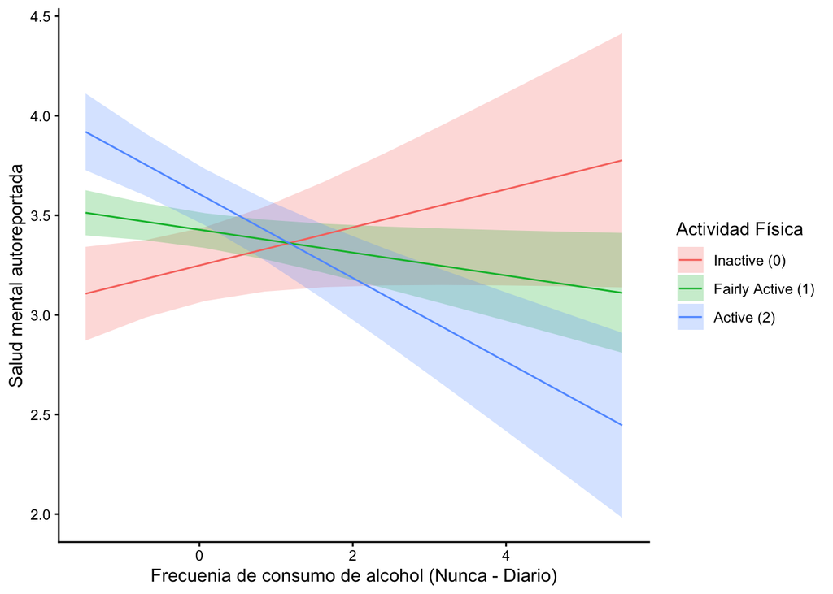

```r
modelbased::estimate_means(model = m2a,
                           by = c("alcohol_freq_cen", "pa_activity_level")) |>
  plot() +
  labs(x = "Frecuenia de consumo de alcohol (Nunca - Diario)",
       y = "Salud mental autoreportada",
       color = "Actividad Física",
       fill = "Actividad Física" ) +
  scale_color_discrete(labels = c("Inactive (0)","Fairly Active (1)","Active (2)")) +
  scale_fill_discrete(labels = c("Inactive (0)","Fairly Active (1)","Active (2)")) +
  theme_classic()
```

## Examinar la misma moderación desde otra perspectiva

#### Pendientes simples (*Simple slope analysis*): efectos simples

- `alcohol_freq_cen` como moderador
- Escogemos valores para probar la interacción (-1SD, Media, +1SD; pero puede ser cualquier valor de interés)

```r
ss_alcohol <- modelbased::estimate_slopes(model = m2a,
                            trend = "pa_activity_level",       # Predictora
                            by = "alcohol_freq_cen=[sd]")      # Moderadora

ss_alcohol
```

```
Estimated Marginal Effects

alcohol_freq_cen | Slope |   SE |        95% CI | t(586) |      p
-----------------------------------------------------------------
-1.70            |  0.44 | 0.10 | [ 0.25, 0.63] |   4.44 | < .001
0.00             |  0.18 | 0.07 | [ 0.04, 0.32] |   2.52 |  0.012
1.70             | -0.08 | 0.10 | [-0.28, 0.12] |  -0.81 |  0.419

Marginal effects estimated for pa_activity_level
Type of slope was dY/dX
```

## Pendientes Simples: Visualiza el tamaño del efecto (`b`)

- Visualiza la tabla anterior (los efectos de la actividad física sobre la salud mental, en función de la frecuencia de consumo de alcohol)

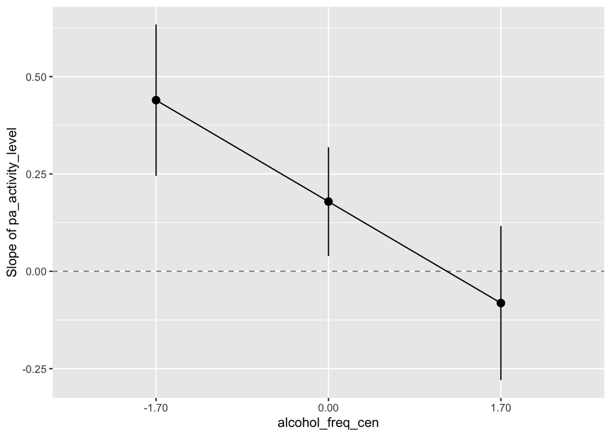

```r
ss_alcohol |>
  plot()
```

## Pendientes Simples: Ver las medias marginales ajustadas (`predicted outcome`)

```r
means_alcohol <- modelbased::estimate_means(model = m2a,
                           by = c("pa_activity_level","alcohol_freq_cen=[sd]"))

# ver los datos
means_alcohol
```

```
Estimated Marginal Means

pa_activity_level | alcohol_freq_cen | Mean |   SE |       95% CI | t(586)
--------------------------------------------------------------------------
0                 |            -1.70 | 3.09 | 0.13 | [2.84, 3.34] |  24.19
1                 |            -1.70 | 3.53 | 0.06 | [3.40, 3.65] |  57.34
2                 |            -1.70 | 3.96 | 0.10 | [3.76, 4.17] |  37.99
0                 |             0.00 | 3.25 | 0.09 | [3.06, 3.43] |  34.53
1                 |             0.00 | 3.43 | 0.04 | [3.34, 3.51] |  77.20
2                 |             0.00 | 3.61 | 0.07 | [3.46, 3.75] |  50.00
0                 |             1.70 | 3.41 | 0.14 | [3.14, 3.68] |  24.75
1                 |             1.70 | 3.33 | 0.06 | [3.20, 3.46] |  51.74
2                 |             1.70 | 3.25 | 0.10 | [3.06, 3.44] |  33.20

Variable predicted: ment_health
Predictors modulated: pa_activity_level, alcohol_freq_cen=[sd]
```

## Pendientes Simples: Visualizar las medias marginales ajustadas (`predicted outcome`)

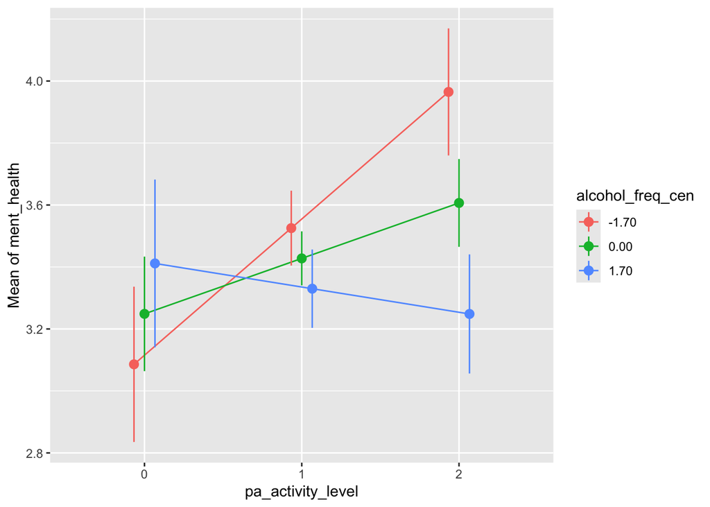

```r
means_alcohol |>
  plot()
```

## Pendientes Simples: Visualizar las medias marginales ajustadas (`predicted outcome`) (ajustado, para publicación)

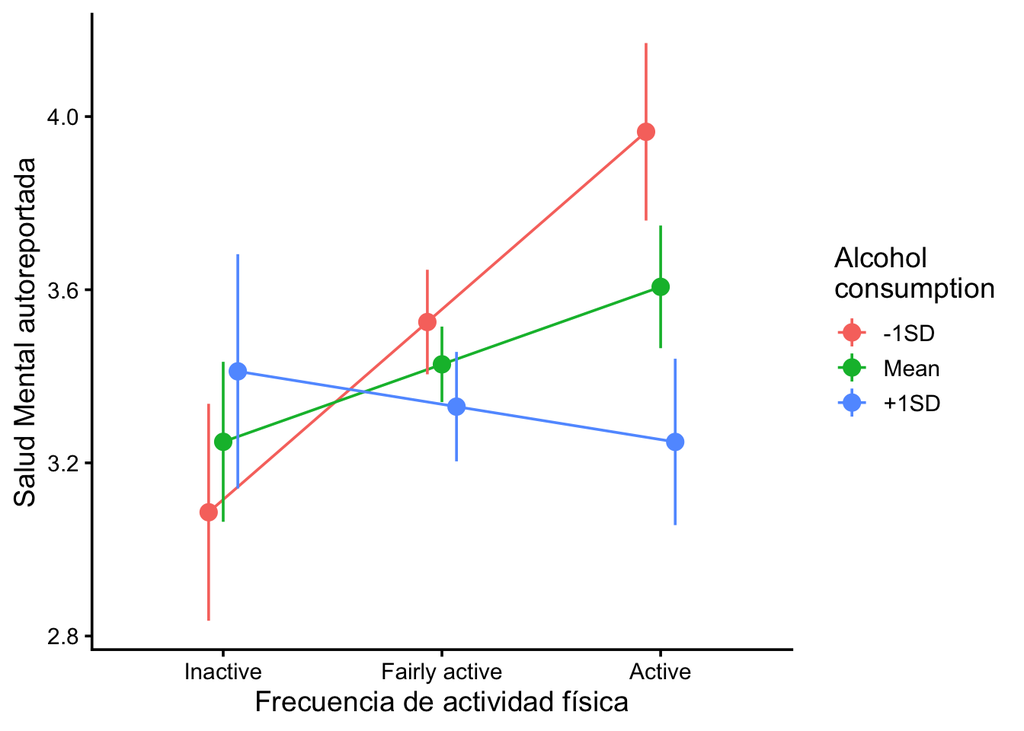

```r
means_alcohol |>
  plot() +
  labs(color = "Alcohol\nconsumption",
       y = "Salud Mental autoreportada",
       x = "Frecuencia de actividad física") +
  scale_x_discrete(labels = c("Inactive", "Fairly active", "Active")) +
  theme_classic(base_size = 14) +
  scale_color_discrete(labels = c("-1SD","Mean","+1SD"))
```

## Regiones de significancia `Johnson-Neyman`: Tabla

```r
jn_alcohol <- modelbased::estimate_slopes(model = m2a,
                            trend = "pa_activity_level",# Predictora
                            by = "alcohol_freq_cen",    # Moderadora
                            length = 100)
summary(jn_alcohol)
```

```
Johnson-Neymann Intervals

Start |  End | Direction | Confidence
------------------------------------------
-1.49 | 0.21 | positive  | Significant
0.28  | 1.13 | positive  | Not Significant
1.20  | 2.97 | negative  | Not Significant
3.04  | 5.51 | negative  | Significant

Marginal effects estimated for pa_activity_level
Type of slope was dY/dX
```

## El tamaño del efecto de `pa_activity_level` a lo largo de 100 valores de `alcohol_freq_cen`. *NOTA: Asumiendo que fuera continua*

```r
jn_alcohol
```

```
Estimated Marginal Effects

alcohol_freq_cen |     Slope |   SE |         95% CI | t(586) |      p
----------------------------------------------------------------------
-1.49            |      0.41 | 0.09 | [ 0.22,  0.59] |   4.37 | < .001
-1.41            |      0.40 | 0.09 | [ 0.22,  0.57] |   4.34 | < .001
-1.34            |      0.38 | 0.09 | [ 0.21,  0.56] |   4.30 | < .001
-1.27            |      0.37 | 0.09 | [ 0.20,  0.55] |   4.27 | < .001
-1.20            |      0.36 | 0.09 | [ 0.19,  0.53] |   4.22 | < .001
-1.13            |      0.35 | 0.08 | [ 0.19,  0.52] |   4.17 | < .001
-1.06            |      0.34 | 0.08 | [ 0.18,  0.50] |   4.12 | < .001
-0.99            |      0.33 | 0.08 | [ 0.17,  0.49] |   4.06 | < .001
-0.92            |      0.32 | 0.08 | [ 0.16,  0.48] |   4.00 | < .001
-0.85            |      0.31 | 0.08 | [ 0.15,  0.46] |   3.92 | < .001
-0.78            |      0.30 | 0.08 | [ 0.15,  0.45] |   3.85 | < .001
-0.71            |      0.29 | 0.08 | [ 0.14,  0.44] |   3.76 | < .001
-0.64            |      0.28 | 0.08 | [ 0.13,  0.42] |   3.67 | < .001
-0.57            |      0.27 | 0.07 | [ 0.12,  0.41] |   3.57 | < .001
-0.49            |      0.25 | 0.07 | [ 0.11,  0.40] |   3.46 | < .001
-0.42            |      0.24 | 0.07 | [ 0.10,  0.39] |   3.34 | < .001
-0.35            |      0.23 | 0.07 | [ 0.09,  0.38] |   3.22 |  0.001
-0.28            |      0.22 | 0.07 | [ 0.08,  0.36] |   3.09 |  0.002
-0.21            |      0.21 | 0.07 | [ 0.07,  0.35] |   2.96 |  0.003
-0.14            |      0.20 | 0.07 | [ 0.06,  0.34] |   2.82 |  0.005
-0.07            |      0.19 | 0.07 | [ 0.05,  0.33] |   2.67 |  0.008
0.00             |      0.18 | 0.07 | [ 0.04,  0.32] |   2.52 |  0.012
0.07             |      0.17 | 0.07 | [ 0.03,  0.31] |   2.36 |  0.019
0.14             |      0.16 | 0.07 | [ 0.02,  0.30] |   2.20 |  0.028
0.21             |      0.15 | 0.07 | [ 0.01,  0.29] |   2.04 |  0.042
0.28             |      0.14 | 0.07 | [-0.01,  0.28] |   1.88 |  0.061
0.35             |      0.12 | 0.07 | [-0.02,  0.27] |   1.71 |  0.087
0.42             |      0.11 | 0.07 | [-0.03,  0.26] |   1.55 |  0.121
0.49             |      0.10 | 0.07 | [-0.04,  0.25] |   1.39 |  0.165
0.57             |      0.09 | 0.08 | [-0.06,  0.24] |   1.23 |  0.220
0.64             |      0.08 | 0.08 | [-0.07,  0.23] |   1.07 |  0.284
0.71             |      0.07 | 0.08 | [-0.08,  0.22] |   0.92 |  0.360
0.78             |      0.06 | 0.08 | [-0.09,  0.21] |   0.76 |  0.446
0.85             |      0.05 | 0.08 | [-0.11,  0.21] |   0.61 |  0.539
0.92             |      0.04 | 0.08 | [-0.12,  0.20] |   0.47 |  0.637
0.99             |      0.03 | 0.08 | [-0.13,  0.19] |   0.33 |  0.740
```

[output cut: 52 more lines]

```
4.74             |     -0.55 | 0.21 | [-0.96, -0.14] |  -2.61 |  0.009
4.81             |     -0.56 | 0.21 | [-0.97, -0.14] |  -2.63 |  0.009
4.88             |     -0.57 | 0.21 | [-0.99, -0.15] |  -2.65 |  0.008
4.95             |     -0.58 | 0.22 | [-1.00, -0.15] |  -2.67 |  0.008
5.02             |     -0.59 | 0.22 | [-1.02, -0.16] |  -2.68 |  0.008
5.09             |     -0.60 | 0.22 | [-1.04, -0.16] |  -2.70 |  0.007
5.16             |     -0.61 | 0.23 | [-1.05, -0.17] |  -2.71 |  0.007
5.23             |     -0.62 | 0.23 | [-1.07, -0.17] |  -2.73 |  0.007
5.30             |     -0.63 | 0.23 | [-1.09, -0.18] |  -2.74 |  0.006
5.37             |     -0.64 | 0.23 | [-1.10, -0.18] |  -2.75 |  0.006
5.45             |     -0.65 | 0.24 | [-1.12, -0.19] |  -2.77 |  0.006
5.51             |     -0.67 | 0.24 | [-1.13, -0.20] |  -2.78 |  0.006

Marginal effects estimated for pa_activity_level
Type of slope was dY/dX
```

## Regiones de significancia `Johnson-Neyman`: Visualización

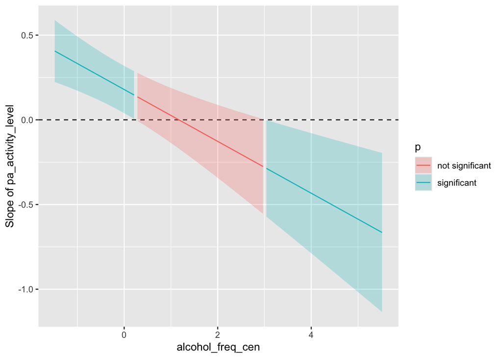

```r
jn_alcohol |>  # efectos a -1SD, la media y +1SD
  plot()
```

## Regiones de significancia `Johnson-Neyman`: Figura (adaptada para publicación)

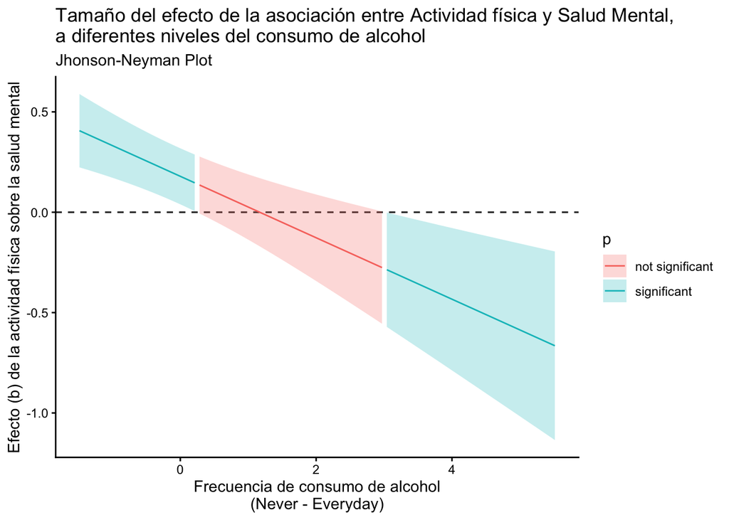

```r
jn_alcohol |>
  plot() +
  labs(x = "Frecuencia de consumo de alcohol\n(Never - Everyday)",
       y = "Efecto (b) de la actividad física sobre la salud mental",
       title = "Tamaño del efecto de la asociación entre Actividad física y Salud Mental,\na diferentes niveles del consumo de alcohol",
       subtitle = "Jhonson-Neyman Plot") +
    theme_classic()
```

# Ejercicio

## Ejercicio: moderación con salud física (20 minutos)

En este ejercicio vamos a evaluar si la relación entre **conexión social** y **salud física** depende de la **etnicidad**.

- Variable dependiente: `phys_health`
- Variable independiente: `social_connect`
- Moderadora: `ethnicity_black`
- Covariables: `gender_female`, `age_group`

### Tareas

1. Preparar las variables necesarias: centrar `social_connect`
2. Estimar un modelo de regresión con efectos simples: predictoras
3. Estimar un modelo con interacción
4. Presentar los resultados en una tabla.
5. Evaluar las pendientes simples.
6. Escribir una conclusión breve.

## Resumen

- La **moderación** permite evaluar si una relación entre dos variables cambia según una tercera variable.
- Estadísticamente, la moderación se analiza mediante una **interacción**.
- Una interacción significativa indica que el efecto de una variable **depende de otra**.
- Los efectos principales deben interpretarse con cuidado cuando hay interacción.
- Centrar las variables continuas ayuda a interpretar mejor los resultados.
- Para entender la interacción, no basta con mirar el coeficiente: hay que examinar las **pendientes simples** o los **efectos marginales**.
- El objetivo final es responder:  
  **¿cuándo, para quién o bajo qué condiciones ocurre el efecto?**